# **Assessing Medical Treatment Effects with Inferential Statistics**

#### Author: Luis Rito Filipe

#### August, 2025

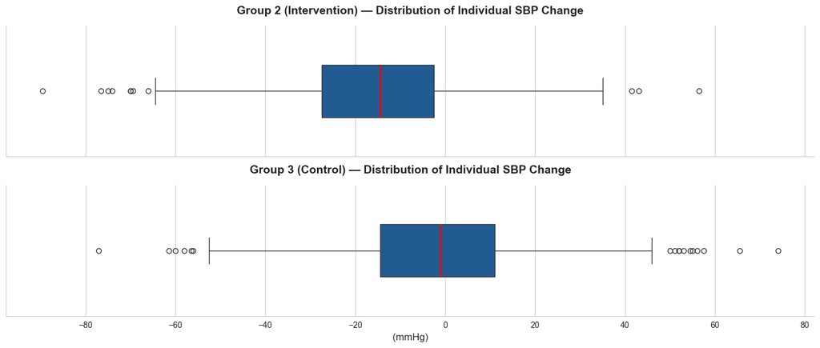

# Summary

This study investigates whether a multifaceted digital intervention for hypertension management was associated with a different change in systolic blood pressure compared with a control group over a 12-month period. The analysis uses patient-level systolic blood pressure measurements at the beginning and end of the study to calculate each participant's individual change. Descriptive statistics are followed by a Welch two-sample t-test and a 95% confidence interval to assess the difference in average individual change between the intervention and control groups.

The intervention group showed a substantially greater reduction in systolic blood pressure, with an observed difference of approximately −13.75 mmHg compared with the control group. The statistical analysis provides very strong evidence of a difference between the groups, with a t-statistic of −14.15 and a p-value of 5.63 × 10⁻⁴³. The corresponding 95% confidence interval ranges from −15.65 to −11.84 mmHg.

The study also examines the assumptions underlying the statistical test and assesses the potential influence of extreme observations.

# About The Study

This project uses the CHESS_database_revise dataset, which contains raw data from the evaluation of the Comprehensive intelligent Hypertension managEment SyStem (CHESS). The data originate from the study “Effect of a multifaceted digital intervention system to improve hypertension management in primary care: an open-label, cluster randomized controlled trial.” The original study evaluated a multifaceted digital intervention designed to improve hypertension management in primary care. The trial used cluster randomization, with participating sites assigned to either the intervention or control group.

The primary objective of this project is not to reproduce the complete statistical methodology of the original clinical trial, but to apply and demonstrate fundamental concepts of inferential statistics, including hypothesis testing, p-values, confidence intervals, and diagnostic assessment.

# About The Dataset

The following study uses the Comprehensive intelligent Hypertension managEment SyStem (CHESS) dataset publicly available from Dryad (see link below), which contains records from a multifaceted digital intervention designed to improve hypertension management in primary care.

Dataset link: https://datadryad.org/dataset/doi:10.5061/dryad.18931zdb7

```python
import pandas as pd
import numpy as np
from scipy.stats import ttest_ind, t, skew, kurtosis
import statsmodels.formula.api as smf
import matplotlib.pyplot as plt
import seaborn as sns

pd.set_option('display.max_rows', None)
pd.set_option('display.max_columns', None)
pd.set_option('display.max_colwidth', None)
```

# Methodology

- Data Wrangling and Pre-processing
- Statistical Question
- Research Question
- The Statistical Hypotheses
- Descriptive Statistics
- Statistical Inference
- Hypotheses Testing Using Welch's t-Test
- Confidence Interval
- Assumptions and Diagnostic Checks
- Interpretation and Limitations
- Conclusions

# Data Wrangling and Pre-processing

The dataset used in this study is the CHESS_database_revise, which contains a large set of systolic and diastolic blood pressure measurements from patients. Only a subset of variables relevant to the present analysis was selected. These variables include the patient group identifier, systolic blood pressure at the start of the experiment, systolic blood pressure at the end of the experiment, the site identifier, the gender and the age group. Summary statistics for these variables are presented below.

```python
df = pd.read_csv("CHESS_database_revise.csv")
df = df[["group", "RAND_SYSBP", "FU_SYSBP_FU4", "SITEID", "Gender", "Age_group"]]
df.info(verbose=False)
df.describe(include="all")
```

```
<class 'pandas.core.frame.DataFrame'>
RangeIndex: 1666 entries, 0 to 1665
Columns: 6 entries, group to Age_group
dtypes: float64(2), int64(3), object(1)
memory usage: 78.2+ KB
```

|  | group | RAND_SYSBP | FU_SYSBP_FU4 | SITEID | Gender | Age_group |
| --- | --- | --- | --- | --- | --- | --- |
| count | 1666.000000 | 1666.000000 | 1660.000000 | 1666.000000 | 1666.000000 | 1666 |
| unique | NaN | NaN | NaN | NaN | NaN | 5 |
| top | NaN | NaN | NaN | NaN | NaN | 50-60 |
| freq | NaN | NaN | NaN | NaN | NaN | 694 |
| mean | 2.490996 | 141.946279 | 133.444277 | 6205.684274 | 0.444778 | NaN |
| std | 0.500069 | 17.077309 | 15.949260 | 77.566029 | 0.497090 | NaN |
| min | 2.000000 | 95.500000 | 91.000000 | 6103.000000 | 0.000000 | NaN |
| 25% | 2.000000 | 130.500000 | 122.500000 | 6113.000000 | 0.000000 | NaN |
| 50% | 2.000000 | 141.000000 | 132.000000 | 6208.000000 | 0.000000 | NaN |
| 75% | 3.000000 | 152.000000 | 143.500000 | 6303.000000 | 1.000000 | NaN |
| max | 3.000000 | 224.500000 | 190.000000 | 6313.000000 | 1.000000 | NaN |

A small number of missing values were identified among the variables required for the analysis. These records were excluded from the statistical analysis.

```python
df.isna().sum().rename_axis("Feature").reset_index(name="Count").query("Count > 0").style.hide(axis="index")
```

| Feature | Count |
| --- | --- |
| FU_SYSBP_FU4 | 6 |

```python
df = df.dropna()
```

# Statistical Question

## Research Question

The objective of this study is to determine whether the CHESS intervention produced a greater reduction in systolic blood pressure than usual care after 12 months. The primary outcome is systolic blood pressure (SBP), measured at baseline and again after 12 months.

Rather than simply comparing the average blood pressure of the two groups at the end of the study, we will examine the change in systolic blood pressure from baseline to 12 months. A negative value therefore represents a reduction in systolic blood pressure.

The treatment effect will then be estimated as the difference between the average individual change in the intervention group and the average individual change in the control group.

The main statistical questions are therefore **"Is the difference in average individual change in systolic blood pressure between the intervention and control groups sufficiently large to provide evidence that the intervention had an effect?"**

This leads to the main statistical tools explored in this study:

- Hypothesis testing, p-values and confidence intervals.

## The Statistical Hypotheses

The null hypothesis is:

- H0: There is no difference between the intervention and control groups in the average individual change in systolic blood pressure.

The alternative hypothesis is:

- H1: There is a difference between the intervention and control groups in the average individual change in systolic blood pressure.

# Descriptive Statistics

The following table presents the number of participants in each group. The intervention group (2) has a slightly larger number of participants than the control group (3).

```python
df['group'].value_counts().reset_index().style.hide(axis="index")
```

| group | count |
| --- | --- |
| 2 | 847 |
| 3 | 813 |

The following table presents descriptive statistics for baseline systolic blood pressure in each group. The intervention group (2) has a slightly higher average baseline systolic blood pressure than the control group (3).

```python
df.groupby('group')['RAND_SYSBP'].agg(['count', 'mean', 'std']).reset_index().style.hide(axis="index")
```

| group | count | mean | std |
| --- | --- | --- | --- |
| 2 | 847 | 143.649351 | 16.915880 |
| 3 | 813 | 140.109471 | 17.075310 |

The following table presents descriptive statistics for systolic blood pressure in each group after 12 months. The intervention group (2) has a substantially lower average systolic blood pressure than the control group (3).

```python
df.groupby('group')['FU_SYSBP_FU4'].agg(['count', 'mean', 'std']).reset_index().style.hide(axis="index")
```

| group | count | mean | std |
| --- | --- | --- | --- |
| 2 | 847 | 128.444510 | 13.990050 |
| 3 | 813 | 138.653137 | 16.203854 |

A new feature, SBP_Change, was created to represent the individual change in systolic blood pressure over the 12-month period, as described earlier. The following table presents descriptive statistics for this variable in the two groups. The intervention group (2) shows a substantially larger reduction in systolic blood pressure on average than the control group (3), while the standard deviations are relatively similar. The difference between the group averages is approximately −13.75 mmHg, calculated as the intervention group average minus the control group average.

```python
df['SBP_Change'] = df['FU_SYSBP_FU4'] - df['RAND_SYSBP']
df.groupby('group')['SBP_Change'].agg(['count', 'mean', 'std']).reset_index().style.hide(axis="index")
```

| group | count | mean | std |
| --- | --- | --- | --- |
| 2 | 847 | -15.204841 | 19.491746 |
| 3 | 813 | -1.456335 | 20.076737 |

The following plots present the distribution of the individual change in systolic blood pressure of the intervention and control groups.

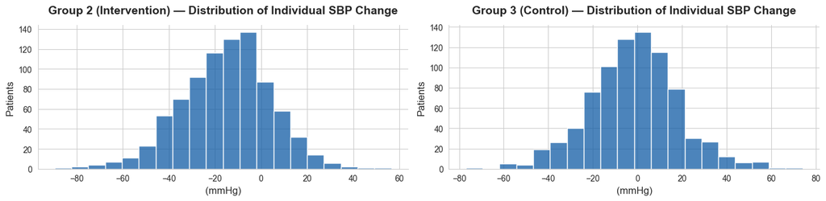

```python
def plot_groups_sysbp_change_distribution(data):
    sns.set_style("whitegrid")
    fig, axes = plt.subplots(1, 2, figsize=(14, 3.5))

    color = sns.color_palette("Blues", n_colors=5)[4]
    sns.histplot(
        data.loc[data["group"].eq(2), "SBP_Change"],
        bins=20,
        color=color,
        edgecolor="white",
        ax=axes[0]
    )
    axes[0].tick_params(axis='x', rotation=0)
    axes[0].set_title("Group 2 (Intervention) — Distribution of Individual SBP Change", fontsize=14, fontweight="bold", pad=14)
    axes[0].set_xlabel("(mmHg)", fontsize=12)
    axes[0].set_ylabel("Patients", fontsize=12)

    sns.histplot(
        data.loc[data["group"].eq(3), "SBP_Change"],
        bins=20,
        color=color,
        edgecolor="white",
        ax=axes[1]
    )
    axes[1].tick_params(axis='x', rotation=0)
    axes[1].set_title("Group 3 (Control) — Distribution of Individual SBP Change", fontsize=14, fontweight="bold", pad=14)
    axes[1].set_xlabel("(mmHg)", fontsize=12)
    axes[1].set_ylabel("Patients", fontsize=12)
    plt.tight_layout()
    sns.despine()
    plt.show()
plot_groups_sysbp_change_distribution(df)
```

To explore whether the observed treatment effect was consistent across demographic groups, the difference in average individual change between the intervention and control groups was calculated separately for each gender and age-group combination.

```python
demographic = df.sort_values("group").groupby(["group", "Gender", "Age_group"]).agg(Count=("Age_group", "count"), Mean=("SBP_Change", "mean"))
demographic = demographic.groupby(["Gender", "Age_group"]).agg(TotalN=("Count", "sum"), MeanDiff=("Mean", lambda x: x.iloc[0] - x.iloc[1])).reset_index()
demographic.style.hide(axis="index")
```

| Gender | Age_group | TotalN | MeanDiff |
| --- | --- | --- | --- |
| 0 | 30-40 | 22 | -16.841880 |
| 0 | 40-50 | 158 | -13.117028 |
| 0 | 50-60 | 342 | -14.669120 |
| 0 | 60-70 | 290 | -13.510155 |
| 0 | 70-80 | 109 | -6.234343 |
| 1 | 30-40 | 16 | -25.071429 |
| 1 | 40-50 | 102 | -12.184982 |
| 1 | 50-60 | 351 | -14.683250 |
| 1 | 60-70 | 206 | -12.800047 |
| 1 | 70-80 | 64 | -19.025616 |

The estimated treatment difference was negative across all gender and age strata, indicating a greater reduction in systolic blood pressure in the intervention group in every subgroup examined. The magnitude of the estimated difference varied between approximately −6.23 and −25.07 mmHg. However, the smaller sample sizes in some strata mean that these differences should be interpreted cautiously and should not be taken as evidence that the treatment effect differs statistically between demographic groups.

# Statistical Inference

Descriptive statistics showed that the intervention group had a mean reduction of -15.205 mmHg, while the control group had a mean reduction of -1.456 mmHg. The observed difference in average individual change was therefore −13.75 mmHg. This difference describes what happened in the study sample. However, the objective of statistical inference is to determine what can reasonably be concluded about the underlying population from which the study participants were drawn. Because different samples, or different random assignments, can produce different results, we need to assess whether the observed difference could reasonably be explained by random variation.

## Hypotheses Testing Using Welch's t-Test

### Overall-Level t-Test

In the next step, the observed difference in mean individual change of −13.75 mmHg were tested against the null hypothesis. Under the null hypothesis, it is assumed that there is no difference in the mean change in SBP between the intervention group and the control group. The hypothesis test results in the following table provides strong evidence against the null hypothesis of no difference in mean SBP change between the two groups (t = −14.15, p < 0.001). Therefore, the observed difference of −13.75 mmHg is statistically significant. The t-statistic value of −14.15 indicates how far the observed difference is from the null hypothesis value, measured in standard errors.

```python
t_test = ttest_ind( df.loc[df['group'] == 2, 'SBP_Change'].dropna(), df.loc[df['group'] == 3, 'SBP_Change'].dropna(), equal_var=False )
pd.DataFrame(t_test, index=["t-statistic", "p-value"], columns=["Value"])
```

|  | Value |
| --- | --- |
| t-statistic | -1.414784e+01 |
| p-value | 5.630134e-43 |

### Gender and Age Group-Level t-Test

To explore whether the evidence for a difference between the intervention and control groups was consistent across demographic subgroups, separate Welch t-tests were performed for each gender and age-group combination. Nine of the ten subgroup comparisons produced statistically significant results at the 5% significance level. The only non-significant comparison was observed for Gender 0 participants aged 70–80 (p = 0.146).

```python
def compute_t_test_by_gender_and_age():
    t_test_by_gender_and_age = df.groupby(["Gender", "Age_group"]).apply( lambda x: ttest_ind( x.loc[x["group"] == 2, "SBP_Change"], x.loc[x["group"] == 3, "SBP_Change"], equal_var=False ), include_groups=False).reset_index(name="TTest")
    t_test_by_gender_and_age["t-statistic"] = t_test_by_gender_and_age["TTest"].apply(lambda x: x.statistic)
    t_test_by_gender_and_age["p-value"] = t_test_by_gender_and_age["TTest"].apply(lambda x: x.pvalue)
    return t_test_by_gender_and_age.drop(columns="TTest")
t_test_by_gender_and_age = compute_t_test_by_gender_and_age()
t_test_by_gender_and_age.style.hide(axis="index")
```

| Gender | Age_group | t-statistic | p-value |
| --- | --- | --- | --- |
| 0 | 30-40 | -2.289131 | 0.033488 |
| 0 | 40-50 | -4.535933 | 0.000012 |
| 0 | 50-60 | -7.062581 | 0.000000 |
| 0 | 60-70 | -5.835202 | 0.000000 |
| 0 | 70-80 | -1.465776 | 0.145691 |
| 1 | 30-40 | -2.448802 | 0.028396 |
| 1 | 40-50 | -2.613294 | 0.011085 |
| 1 | 50-60 | -7.151044 | 0.000000 |
| 1 | 60-70 | -4.649111 | 0.000006 |
| 1 | 70-80 | -3.106248 | 0.003073 |

## Confidence Interval

### Overall Confidence Interval

While the hypothesis test assesses whether there is evidence of a difference between the two groups, a confidence interval provides an estimate of the plausible range for the difference in average individual change in systolic blood pressure. A 95% confidence interval was calculated for the difference between the intervention and control groups. The calculation uses Welch's method, which does not assume that the two groups have equal variances. The observed difference was calculated as the average individual change in the intervention group minus the average individual change in the control group. The resulting confidence interval is presented below.

```python
def compute_confidence_intervals_and_diagnostics_at_global_level():
    group_2 = df.loc[df['group'] == 2, 'SBP_Change'].dropna()
    group_3 = df.loc[df['group'] == 3, 'SBP_Change'].dropna()
    len_2 = len(group_2)
    len_3 = len(group_3)
    mean_2 = group_2.mean()
    mean_3 = group_3.mean()
    std_2 = group_2.std()
    std_3 = group_3.std()
    observed_diff = mean_2 - mean_3
    std_error = np.sqrt( (std_2**2 / len_2) + (std_3**2 / len_3) )
    degree_of_freedom_welch = (std_2**2 / len_2 + std_3**2 / len_3)**2 / ( (std_2**2 / len_2)**2 / (len_2 - 1) + (std_3**2 / len_3)**2 / (len_3 - 1) )
    t_critical = t.ppf(0.975, degree_of_freedom_welch)
    margin_of_error = t_critical * std_error
    lower = observed_diff - margin_of_error
    upper = observed_diff + margin_of_error

    diagnostics = pd.DataFrame({
        'Group 2': [ len(group_2), group_2.mean(), group_2.std(), skew(group_2), kurtosis(group_2) ],
        'Group 3': [ len(group_3), group_3.mean(), group_3.std(), skew(group_3), kurtosis(group_3) ]
    }, index=[ 'n', 'Mean', 'Standard deviation', 'Skewness', 'Excess kurtosis' ])

    return pd.DataFrame([lower, upper], index=["Lower", "Upper"], columns=["Confidence interval"]), diagnostics
confidence_interval, diagnostics = compute_confidence_intervals_and_diagnostics_at_global_level()
confidence_interval
```

|  | Confidence interval |
| --- | --- |
| Lower | -15.654547 |
| Upper | -11.842465 |

The 95% confidence interval ranges from −15.65 mmHg to −11.84 mmHg. This indicates that the difference in average individual change is estimated to lie within this range, with the intervention group showing a greater reduction in systolic blood pressure than the control group. The entire confidence interval lies below zero, consistent with the rejection of the null hypothesis. Because the difference is calculated as intervention minus control, the negative values indicate a greater reduction in systolic blood pressure in the intervention group.

### Gender and Age Group Confidence Interval

The following subgroup analysis shows that the estimated difference in average individual systolic blood pressure change was negative across all gender and age-group combinations, indicating a greater reduction in the intervention group. Nine of the ten subgroup comparisons were statistically significant at the 5% level, with confidence intervals excluding zero. The only non-significant result was observed among Gender 0 participants aged 70–80, for whom the confidence interval included zero. These subgroup analyses provide an assessment of whether the overall treatment effect was broadly consistent across demographic groups.

```python
def compute_confidence_intervals_at_gender_and_age_group_level():
    ci = df.sort_values("group").groupby(["group", "Gender", "Age_group"]).agg(
        Count=("Age_group", "count"),
        Mean=("SBP_Change", "mean"),
        Std=("SBP_Change", "std")
    ).reset_index()

    observed_diff = ci.loc[ci["group"].eq(2), "Mean"].to_numpy() - ci.loc[ci["group"].eq(3), "Mean"].to_numpy()
    len_2 = ci.loc[ci["group"].eq(2), "Count"].to_numpy()
    len_3 = ci.loc[ci["group"].eq(3), "Count"].to_numpy()
    std_2 = ci.loc[ci["group"].eq(2), "Std"].to_numpy()
    std_3 = ci.loc[ci["group"].eq(3), "Std"].to_numpy()
    std_error = np.sqrt( (std_2**2 / len_2) + (std_3**2 / len_3) )
    degree_of_freedom_welch = (std_2**2 / len_2 + std_3**2 / len_3)**2 / ( (std_2**2 / len_2)**2 / (len_2 - 1) + (std_3**2 / len_3)**2 / (len_3 - 1) )
    t_critical = t.ppf(0.975, degree_of_freedom_welch)
    margin_of_error = t_critical * std_error
    lower = observed_diff - margin_of_error
    upper = observed_diff + margin_of_error

    return pd.DataFrame({"Gender" : np.r_[np.zeros(5, dtype=int), np.ones(5, dtype=int)], "Age_group" : np.tile( ci["Age_group"].iloc[0:5].to_numpy(), 2) , "Lower Confidence Interval" : lower, "Upper Confidence Interval" : upper}) #diagnostics
confidence_interval = compute_confidence_intervals_at_gender_and_age_group_level()
group_level = demographic[["Gender", "Age_group", "MeanDiff", "TotalN"]].merge(t_test_by_gender_and_age, on=["Gender", "Age_group"], how="left")
group_level = group_level.merge(confidence_interval, on=["Gender", "Age_group"], how="left")
group_level.style.hide(axis="index")
```

| Gender | Age_group | MeanDiff | TotalN | t-statistic | p-value | Lower Confidence Interval | Upper Confidence Interval |
| --- | --- | --- | --- | --- | --- | --- | --- |
| 0 | 30-40 | -16.841880 | 22 | -2.289131 | 0.033488 | -32.223353 | -1.460408 |
| 0 | 40-50 | -13.117028 | 158 | -4.535933 | 0.000012 | -18.831213 | -7.402844 |
| 0 | 50-60 | -14.669120 | 342 | -7.062581 | 0.000000 | -18.754825 | -10.583415 |
| 0 | 60-70 | -13.510155 | 290 | -5.835202 | 0.000000 | -18.067869 | -8.952442 |
| 0 | 70-80 | -6.234343 | 109 | -1.465776 | 0.145691 | -14.667570 | 2.198883 |
| 1 | 30-40 | -25.071429 | 16 | -2.448802 | 0.028396 | -47.069377 | -3.073480 |
| 1 | 40-50 | -12.184982 | 102 | -2.613294 | 0.011085 | -21.493521 | -2.876442 |
| 1 | 50-60 | -14.683250 | 351 | -7.151044 | 0.000000 | -18.722073 | -10.644426 |
| 1 | 60-70 | -12.800047 | 206 | -4.649111 | 0.000006 | -18.228627 | -7.371467 |
| 1 | 70-80 | -19.025616 | 64 | -3.106248 | 0.003073 | -31.317597 | -6.733635 |

## Assumptions and Diagnostic Checks

Before interpreting the results of the statistical analysis, the assumptions underlying the two-sample Welch t-test were considered. These include independence of observations, an appropriate quantitative outcome, and an approximately normal sampling distribution of the difference in group means. The data were also examined for potential outliers that could disproportionately influence the results.

Some assumptions, such as independence, depend primarily on the study design and cannot be established from the observed data alone. Other characteristics, such as the distribution and presence of extreme observations, can be assessed using the available data.

### Quantitative Outcome

The outcome variable, SBP_Change, represents the individual change in systolic blood pressure over the 12-month period and is measured in mmHg. As a quantitative continuous variable, it is appropriate for comparing the average individual change between the intervention and control groups.

### Approximate Normality

The distribution of SBP_Change was assessed separately for each group using skewness and excess kurtosis. Both groups show low skewness, with values of −0.182 for the intervention group and 0.042 for the control group. Excess kurtosis was 0.438 and 0.651, respectively, indicating only moderate deviation from the kurtosis of a normal distribution. Given these results and the relatively large sample sizes of 847 and 813 participants, there is no indication of a substantial departure from normality that would threaten the validity of the Welch t-test.

```python
diagnostics
```

|  | Group 2 | Group 3 |
| --- | --- | --- |
| n | 847.000000 | 813.000000 |
| Mean | -15.204841 | -1.456335 |
| Standard deviation | 19.491746 | 20.076737 |
| Skewness | -0.182346 | 0.042285 |
| Excess kurtosis | 0.438428 | 0.651440 |

### Outliers

Potential outliers in SBP_Change were identified separately for each group using the 1.5 × IQR criterion. Eleven observations (1.30%) were identified in the intervention group, while 17 observations (2.09%) were identified in the control group. Although these observations represent unusually large individual changes, they account for only a small proportion of the observations in either group. Potential outliers were not automatically removed, as an extreme value does not necessarily indicate an erroneous observation. Unless there is evidence that an observation results from a measurement or data-entry error, it should be retained in the analysis. A sensitivity analysis was subsequently performed to assess whether these potential outliers materially affect the statistical conclusions.

```python
def outliers():
    def outlier_diagnostics(series):
        q1 = series.quantile(0.25)
        q3 = series.quantile(0.75)
        iqr = q3 - q1
        lower_bound = q1 - 1.5 * iqr
        upper_bound = q3 + 1.5 * iqr
        outliers = series[(series < lower_bound) | (series > upper_bound)]

        return pd.Series({
            'Q1': f"{q1:.2f}",
            'Q3': f"{q3:.2f}",
            'IQR': f"{iqr:.2f}",
            'Lower bound': f"{lower_bound:.2f}",
            'Upper bound': f"{upper_bound:.2f}",
            'Number of potential outliers': len(outliers),
            'Percentage of potential outliers': f"{len(outliers) / len(series) * 100:.2f}"
        })
    group_2 = df.loc[df['group'] == 2, 'SBP_Change'].dropna()
    group_3 = df.loc[df['group'] == 3, 'SBP_Change'].dropna()

    return pd.DataFrame({ 'Group 2': outlier_diagnostics(group_2), 'Group 3': outlier_diagnostics(group_3) })
outlier_results = outliers()
outlier_results
```

|  | Group 2 | Group 3 |
| --- | --- | --- |
| Q1 | -27.50 | -14.50 |
| Q3 | -2.50 | 11.00 |
| IQR | 25.00 | 25.50 |
| Lower bound | -65.00 | -52.75 |
| Upper bound | 35.00 | 49.25 |
| Number of potential outliers | 11 | 17 |
| Percentage of potential outliers | 1.30 | 2.09 |

The following boxplots show that the intervention group is centered considerably lower than the control group, consistent with the difference observed in the table above. A small number of observations extend beyond the whiskers in both groups, indicating potential outliers.

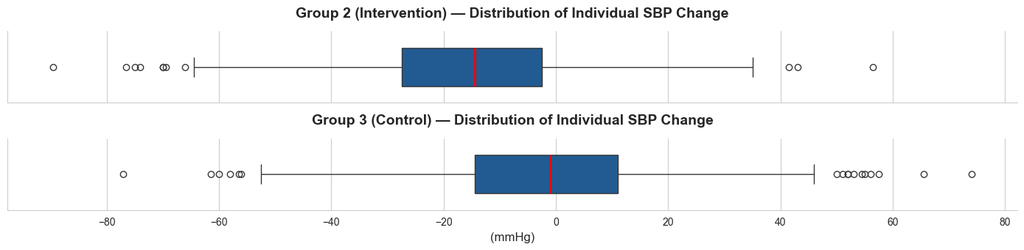

```python
def plot_groups_sysbp_change_boxplot(data):
    sns.set_style("whitegrid")
    fig, axes = plt.subplots(2, 1, figsize=(14, 3.5), sharex=True)
    color = sns.color_palette("Blues", n_colors=5)[4]
    sns.boxplot(
        data.loc[data["group"].eq(2), "SBP_Change"],
        orient="h",
        medianprops=dict(color="Red", linewidth=2),
        color=color,
        ax=axes[0]
    )
    axes[0].tick_params(axis='x', rotation=0)
    axes[0].set_title("Group 2 (Intervention) — Distribution of Individual SBP Change", fontsize=14, fontweight="bold", pad=14)
    axes[0].set_xlabel("(mmHg)", fontsize=12)
    axes[0].set_ylim(-0.75, 0.75)
    sns.boxplot(
        data.loc[data["group"].eq(3), "SBP_Change"],
        orient="h",
        medianprops=dict(color="Red", linewidth=2),
        color=color,
        ax=axes[1]
    )
    axes[1].tick_params(axis='x', rotation=0)
    axes[1].set_title("Group 3 (Control) — Distribution of Individual SBP Change", fontsize=14, fontweight="bold", pad=14)
    axes[1].set_xlabel("(mmHg)", fontsize=12)
    axes[1].set_ylim(-0.75, 0.75)

    plt.tight_layout()
    sns.despine()
    plt.show()
plot_groups_sysbp_change_boxplot(df)
```

A sensitivity check excluding the potential outliers produced a very similar result (t = −14.37, p < 0.001), compared with the original result (t = −14.15, p < 0.001). This indicates that the statistical conclusion is not materially influenced by the potential outliers. Therefore, the identified observations were retained in the main analysis.

```python
def sensitivity_check(outlier_results):
    group_2 = df.loc[df['group'] == 2, 'SBP_Change'].dropna()
    group_3 = df.loc[df['group'] == 3, 'SBP_Change'].dropna()
    outlier_results = outlier_results.astype(float)
    group_2_no_outliers = group_2[ (group_2 >= outlier_results.loc['Lower bound', 'Group 2']) & (group_2 <= outlier_results.loc['Upper bound', 'Group 2']) ]
    group_3_no_outliers = group_3[ (group_3 >= outlier_results.loc['Lower bound', 'Group 3']) & (group_3 <= outlier_results.loc['Upper bound', 'Group 3']) ]
    t_test_without_outliers = ttest_ind(group_2_no_outliers, group_3_no_outliers, equal_var=False )

    return pd.DataFrame(t_test_without_outliers, index=["t-statistic", "p-value"], columns=["Value"])
sensitivity_check(outlier_results)
```

|  | Value |
| --- | --- |
| t-statistic | -1.436580e+01 |
| p-value | 3.786487e-44 |

# Interpretation and Limitations

The analysis provides strong evidence of a difference in the average individual change in systolic blood pressure between the intervention and control groups. The intervention group showed a substantially greater reduction, with an observed difference of approximately −13.75 mmHg, calculated as the intervention group average minus the control group average.

The Welch t-test produced a t-statistic of approximately −14.15 and a p-value of approximately 5.63 × 10⁻⁴³, providing very strong evidence against the null hypothesis of no difference between the groups. This finding is consistent with the 95% confidence interval for the difference, which ranges from approximately −15.65 to −11.84 mmHg and does not include zero.

The confidence interval provides an estimate of the plausible range for the population difference in average individual change. Based on the sample data and the assumptions of the analysis, the difference is estimated to be between approximately −15.65 and −11.84 mmHg. Because the difference was defined as intervention minus control, the negative values indicate a greater reduction in systolic blood pressure in the intervention group.

The underlying study was a cluster randomized controlled trial, with randomization performed at the site level. This study design supports the interpretation of differences between the intervention and control groups as evidence of an intervention effect. The present analysis focuses on the difference in average individual change using a two-sample Welch t-test and does not explicitly account for the clustering of participants within sites.

The analysis also relies on the assumptions underlying the Welch t-test. The diagnostic assessment found no substantial concern regarding the quantitative nature of the outcome, approximate normality, or the presence of extreme observations. The sensitivity check further indicated that the potential outliers did not materially affect the statistical conclusion.

Finally, the analysis focuses on the average individual change in systolic blood pressure over the 12-month period. This provides a summary measure of the difference between the two groups but does not capture the full variability of individual responses.

# Conclusions

This study investigated whether the intervention and control groups differed in their average individual change in systolic blood pressure over a 12-month period.

The intervention group showed a substantially greater reduction in systolic blood pressure, with an observed difference of approximately −13.75 mmHg compared with the control group. The Welch t-test resulted in a t-statistic of approximately −14.15 and a p-value of approximately 5.63 × 10⁻⁴³. At the 5% significance level, the null hypothesis of no difference is therefore rejected.

The corresponding 95% confidence interval ranged from approximately −15.65 to −11.84 mmHg, indicating that the difference in average individual change is consistently negative across the estimated interval.

Overall, the statistical analysis provides strong evidence of a difference in average individual change in systolic blood pressure between the intervention and control groups, with the intervention group experiencing the greater reduction.